#### kilometer’s

a junk space

[研究関連] [R関連]

home

#### 研究に関する内容

- [Google Scholar](https://scholar.google.com/citations?user=NW6HfYgAAAAJ&hl=en)
- [Researchmap](https://researchmap.jp/_km)
- [研究業績リスト](https://github.com/kilometer0101/CurriculumVitae)

### **1. 機械学習を用いた行動ダイナミクスの計算論的記述**

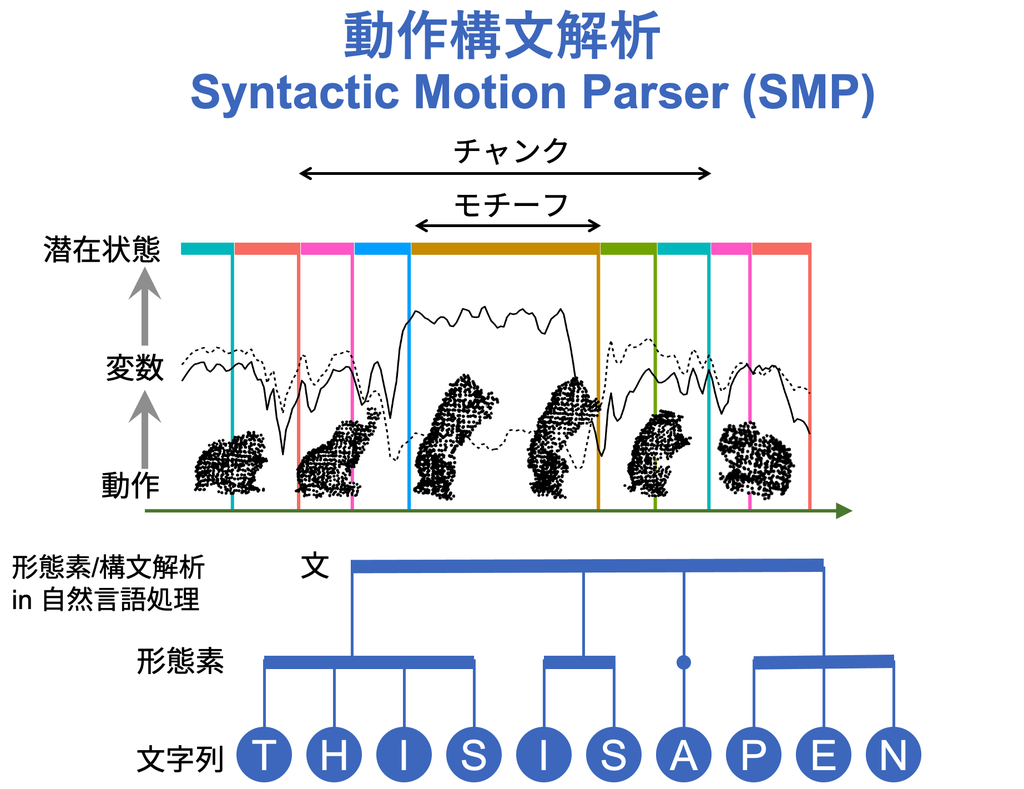

「心が躍る」「目は口ほどに物を言う」といった慣用句がありますが私たちの動作や姿勢などの身体表現は心理的な内部状態（感情、意図、動機、意思など）と強く結びついています。私たちは心的状態に基づいて行動の様式を変容させ、また他者の行動からその心的状態を推定することができ、この機能は社会的コミュニケーションにおいて核となっています。従って多様で複雑な行動表現の全貌を網羅的・定量的に解析する手段が提供されることにより、コミュニケーションダイナミクスの包括的な記述や、社会脳など神経基盤の解明において有用な貢献となると期待されます。我々は、霊長類の身体運動情報を3Dモーショントラッキングにより取得し、その時系列に内在する行動を構成する「単語」や「文法」をデータ駆動に推定する教師なし学習アルゴリズム SyntacticMotionParser (SMP) を開発しました。これは連続した文字列から意味単位である形態素や構文構造を探索する自然言語処理と対照可能なアルゴリズムです。2種類の霊長類の全身運動をSMPを用いて解析した結果を論文にまとめて出版しました(論文1-1, proceedings1-1)。この技術を基盤に、動物の社会行動解析や臨床における当事者の行動データ分析への応用を展開しています。

電気通信大学の[中村友昭先生](https://hp.naka-lab.org/)の主導で、コアとなるアルゴリズムに乱択化フーリエ特徴(RFF)を組み込むことで計算過程が高速化しました(proceedings2-2)。さらに、高速化したアルゴリズムを用い、ヒトの動作を比較し、習熟度を可視化することに成功しました。本手法の実装例として、競技ダンスの動作解析を行い、習熟度に依存した行動の質的変化を可視化することに成功しました(論文1-2)。

- **論文1-1：Unsupervised decomposition of natural monkey behavior into a sequence of motion motifs**  
  **K. Mimura**, J. Matsumoto, D. Mochihashi, T. Nakamura, H. Nishijo, M. Higuchi, T. Hirabayashi, T. Minamimoto, (2024) *Communications Bilogy* [[link]](https://www.nature.com/articles/s42003-024-06786-2)
- **論文1-2：Sequential unsupervised motion segmentation for skill evaluation and comparison**  
  K. Kajiwara, I. Saito, T. Nakamura, D. Mochihashi, **K. Mimura**; IEEE Access, 13, 218055-218065 (2025)[[link]](https://doi.org/10.1109/ACCESS.2025.364492)
- **proceedings1-1：身体動作時系列の分節推移構造推定**  
  **三村喬生**, 中村友昭, 松本惇平, 西条寿夫, 須原哲也, 持橋大地, 南本敬史 (2019) 第33回人工知能学会全国大会 [[link]](https://www.jstage.jst.go.jp/article/pjsai/JSAI2019/0/JSAI2019_1C4J301/_pdf)
- **proceedings2-2： Scalable Unsupervised Segmentation via Random Fourier Feature-based Gaussian Process**  
  I. Saito, M. Nagano, T. Nakamura, D. Mochihashi, **K. Mimura**, IECON, S69-I-TT08-2, IECON25-000290, 17 Oct. 2025 (Madrid, Spain) [[link]](https://doi.org/10.48550/arXiv.2507.10632)

### **2. 化学遺伝学：神経回路の操作**

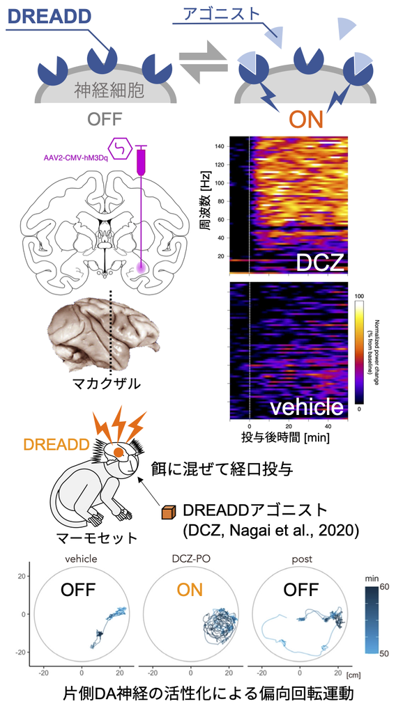

化学遺伝学(chemogenetics)は、神経活動に介入し操作する方法の1つです。これはDREADDと呼ばれる人工的な変異を組み込んだ受容体タンパク質をウィルスベクタを用いて脳の局所に導入し、細胞膜上に発現させる手法です。DREADDは特定の人工薬剤と結合することで細胞内シグナル伝達を活性化させ神経細胞の活動を変化させます。この薬剤のことをDREADDのアゴニストと呼びます。所属チームは2020年にデスクロロクロザピン(Deschloroclozapine, DCZ)という新規のDREADDアゴニストを開発しました。これは結合特異性・脳移行性・代謝頑強性などの点において既存の薬剤と比べ非常に優れた性能を示しました。更に、放射性標識を施した[11C]DCZはPETリガンドとして利用可能であり、脳内でDREADDが発現している神経細胞集団の位置や範囲を特定することが可能となりました(論文2-1)。

マカクザル(*Macaca fascicularis*)を対象に、人為的に誘導された癲癇発作を化学遺伝学を用いて抑制するという研究に参画しました(論文2-3)。難治(薬剤抵抗性)てんかんの治療に向けた応用可能性を拡げる研究成果となりました。当該研究ではデータ科学担当として、化学遺伝学による発作の抑制効果を数理モデルにより定量評価しました(Fig. 3)。オープンアクセスですのでどなたでもご覧いただけます。

- **論文2-1：新規DREADDアゴニストDCZ**  
  **Deschloroclozapine, a potent and selective chemogenetic actuator enables rapid neuronal and behavioral modulations in mice and monkeys**  
  Y.Nagai,N.Miyakawa,H.Takuwa,Y.Hori,K.Oyama,B.Ji,M.Takahashi,X.Huang,S. T Slocum, J. F DiBerto, Y. Xiong, T. Urushihata, T. Hirabayashi, A. Fujimoto, **K. Mimura**, J. G English, J. Liu, K. Inoue, K. Kumata, C. Seki, M. Ono, M. Shimojo, M. Zhang, Y. Tomita, J. Nakahara, T. Suhara, M. Takada, M. Higuchi, J. Jin, B. L Roth, T. Minamimoto (2020) *Nature neuroscience* 23, 1157-1167 [[link]](https://www.nature.com/articles/s41593-020-0661-3) [[プレスリリース]](https://www.qst.go.jp/site/press/42113.html)
- **論文2-2：マーモセットにおける化学遺伝学の実装**  
  **Chemogenetic activation of nigrostriatal dopamine neurons in freely moving common marmosets**  
  **K. Mimura**, Y. Nagai, K. Inoue, J. Matsumoto, Y. Hori, C. Sato, K. Kimura, T. Okauchi, T. Hirabayashi, H. Nishijo, N. Yahata, M. Takada, T. Suhara, M. Higuchi, T. Minamimoto (2021) *iScience*, 24(9), 103066 [[link]](https://doi.org/10.1016/j.isci.2021.103066)
- **論文2-3：マカクザルを対象とした化学遺伝学による癲癇発作の抑制**  
  **Chemogenetic attenuation of cortical seizures in primates**  
  N. Miyakawa, Y. Nagai, Y. Hori, **K. Mimura**, A. Orihara, K. Oyama, T. Matsuo, K. Inoue, T. Suzuki, T. Hirabayashi, T. Suhara, M. Takada, M. Higuchi, K. Kawasaki, T. Minamimoto, *Nature Communications* 14(1) 971 (2023) [[link]](https://www.nature.com/articles/s41467-023-36642-6) [[プレスリリース]](https://www.qst.go.jp/site/press/20230228.html)

### 3. 自閉症スペクトラムおよびそのモデル動物研究

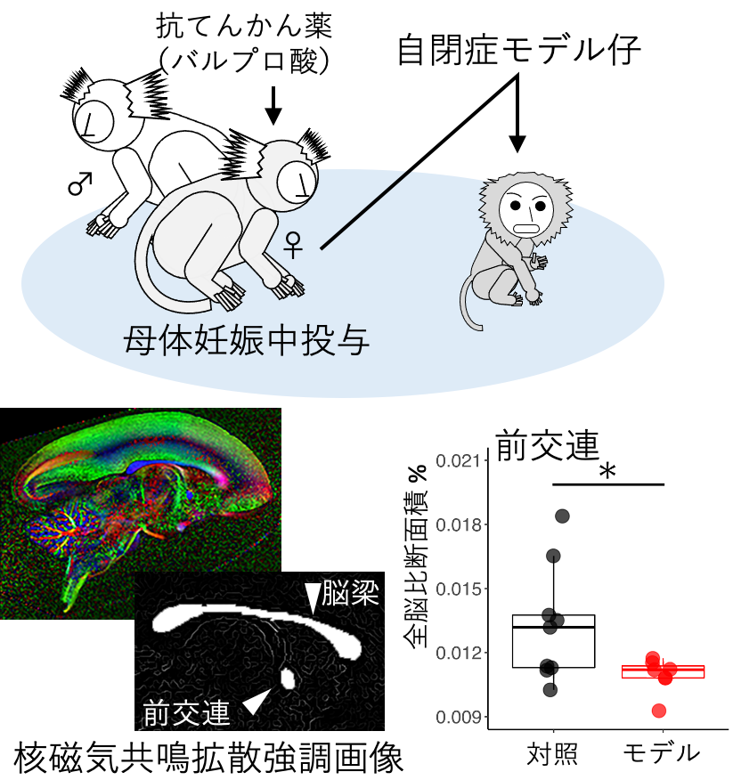

自閉症スペクトラム(ASD)は固執性と社会的コミュニケーションの顕著な障害を特徴とし、有症率約1%と見積もられる主要な精神疾患の1つですが、その表現系の多様性や生後発達に伴う症状の変容から、疾患病態や神経生理学的基盤についての理解は発展途上です。

我々は、独自の多変量行動解析系を用いてASD患者が他者と対面する際に、その属性（既知・未知）に応じて行動を調整する機能に障害を示すことを明らかにしました（論文3-2）。更に、ASDの神経基盤を探索するために自閉症モデル霊長類（マーモセット）の神経構造イメージング研究を行ないました。このモデル動物は胎生期バルプロ酸暴露法を霊長類に応用して作出されました。生後初期脳の神経繊維を高解像度の拡散強調画像(DTI)により可視化・定量することで左右の脳半球を接続する前交連繊維の発達異常が見出されました。また同時期の大脳皮質における遺伝子発現を網羅的に解析した結果、広い領域において軸索伸長因子の発現低下が認められたことと併せ、発達初期における神経構造に関するリスクが明らかになりました（論文3-3, 右図）。

このバルプロ酸暴露法により作出された自閉症様マーモセット(VPAマーモ)が、家族のもとで発育する過程で、家族内のコミュニケーションに影響を与えるかどうかを検証しました。16匹の仔とその両親について音声を網羅的に分析した結果、対照群と比べて、発育期全体を通じた緊張性の音声(phee)の増加、親和的音声(trill)の減少がみられました。さらに、連続して鳴かれる音声列の多様性を手がかりに判別分析を行うと、仔の離乳を経たあとの時期に、対照群とVPAマーモの家族を明瞭に区別することができました。この時期に仔育てを担う父親個体の体重が減少していることから、家族内のストレスが増加している可能性が示唆されました。これらの傾向は、仔の自閉症特性が養育負荷に影響を与えた結果と考えられます（論文3-1）。

また、この他に社会性機能の障害を伴うモデル動物として、社会的孤立環境で発育した家禽雛(ヒヨコ)が示す社会行動および神経構造の異常について大学院修士・博士課程を通じて研究し、主著論文を出版しました（論文3-4）。

- **論文3-1：自閉症モデル霊長類にみられる家族性音声の変容** **Altered kinship vocal dynamics in marmosets with valproic acid-induced model of autism**  
  Koki Mimura, Keiko Nakagaki, Hirofumi Morishita, Noritaka Ichinohe (2026) *iScience*, 29(4), 115419 [[link]](https://www.sciencedirect.com/science/article/pii/S2589004226007947?via%3Dihub)[プレスリリース]
- **論文3-2：自閉症スペクトラム児の対人行動分析**  
  **A cross-species socio-emotional behaviour development revealed by a multivariate analysis**  
  M. Koshiba, A. Senoo, **K. Mimura**, Y. Shirakawa, G. Karino, S. Obara, S. Ozawa, H. Sekihara, Y. Fukushima, T. Ueda, H. Kishino, T. Tanaka, H. Ishibashi, H. Yamanouchi, K. Yui, S. Nakamura (2013) *Scientific reports*, 3, 1-7 [[link]](https://www.nature.com/articles/srep02630)
- **論文3-3：自閉症モデル霊長類の発生初期における神経発達リスク**  
  **Abnormal axon guidance signals and reduced interhemispheric connection via anterior commissure in neonates of marmoset ASD model**  
  **K. Mimura**, T. Oga, T. Sasaki, K. Nakagaki, C. Sato, K. Sumida, K. Hoshino, K. Saito, I. Miyawaki, T. Suhara, I. Aoki, T. Minamimoto, N. Ichinohe (2019) *NeuroImage*, 195, 243-251 [[link]](https://www.sciencedirect.com/science/article/pii/S1053811919302927)
- **論文3-4：社会性障害家禽雛における社会行動の生後発達**  
  **A flexion period for attachment formation in isolated chicks to unfamiliar peers visualized in a developmental trajectory space through behavioral multivariate correlation analysis**  
  **K. Mimura**, S. Nakamura, M. Koshiba (2013) *Neuroscience letters*, 547, 70-75 [[link]](https://www.sciencedirect.com/science/article/abs/pii/S0304394013004291)

### **マーモセット関連**

- **論文：社会性行動の生後発達過程に対する社会的環境の影響を評価**  
  **Reading marmoset behavior ‘semantics’ under particular social context by multi-parameters correlation analysis**  
  M. Koshiba, **K. Mimura**, Y. Sugiura, T. Okuya, A. Senoo, H. Ishibashi, S. Nakamura (2011) *Progress in Neuro-Psychopharmacology and Biological Psychiatry*, 35, 1499-1504 [[link]](https://www.sciencedirect.com/science/article/abs/pii/S0278584611000303)

### **マカクザル関連**

- **論文：尾状核における遅延報酬価値の表現**  
  **Single caudate neurons encode temporally discounted value for formulating motivation for action**  
  Y. Hori, **K. Mimura**, Y. Nagai, A. Fujimoto, K. Oyama, E. Kikuchi, K. Inoue, M. Takada, T. Suhara, BJ. Richmond, T. Minamimoto (2021) *eLife*, 10, e61248 [[link]](https://elifesciences.org/articles/61248)

### **ヒト対象研究**

- **論文：作業行動センサリングと心理スコアの相関構造**  
  **Potential of a smartphone as a stress-free sensor of daily human behaviour**  
  **K. Mimura**, H. Kishino, G. Karino, E. Nitta, A. Senoo, K. Ikegami, T. Kunikata, H. Yamanouchi, S. Nakamura, K. Sato, M. Koshiba (2015) Behavioural Brain Research, 276, 181-189 [[link]](https://www.sciencedirect.com/science/article/abs/pii/S0166432814003817?via%3Dihub)

### **家禽ヒヨコ関連**

- **論文：既知・未知の相手に応じた音声の鳴き分け**  
  **Familiarity perception call elicited under restricted sensory cues in peer-social interactions of the domestic chick**  
  M. Koshiba, Y. Shirakawa, **K. Mimura**, A. Senoo, G. Karino, S. Nakamura (2013) PloS One, 8, e58847 [[link]](https://journals.plos.org/plosone/article?id=10.1371/journal.pone.0058847)